# The American Community Survey

Three windows onto the same country, one of them closed, and a margin beside every number that has one

Democracy’s Data

Last updated September 13, 2026 at 10:53a EDT

The decennial chapter ended on a short list of things the census does not ask: income, education, language, occupation, commuting, disability, ancestry. Every one of them is asked here.

The American Community Survey is where nearly everything people call “census data” actually comes from. The Census Bureau publishes it, on the Bureau’s website, in the Bureau’s house style — and it is **a survey**, with all the properties the source chapter gave that word. Roughly 3.5 million addresses a year, continuously, forever.[^1]

That word decides everything else in this chapter. An enumeration tries to reach every person, and what comes out is a count. A survey reaches a **sample**: a fraction of the country, chosen so that every kind of place has a known chance of being picked. What comes out is an **estimate**, a number that would have come out a little differently had a different sample been drawn.

The ACS says how differently. Beside every estimate it publishes a **margin of error**, how far off the number could be and still be doing its job. The Bureau’s margins are set so that nine times in ten, the true figure lies within that distance of the estimate.[^2] A count is published with no margin. An estimate always has one, and that difference runs through every table below.

| The question | Decennial census | American Community Survey |
| --- | --- | --- |
| Who is asked? | Everyone | A sample: about 3.5 million addresses a year |
| Must you answer? | Yes – required by law, 13 U.S.C. 221 | Yes – required by law, the same statute |
| How often? | Once a decade, as of one day | Continuously, published every year |
| What comes out? | Counts | Estimates |
| How many people live on this block? | Yes – this is the thing only it can do | No – the sample is far too thin |
| What is the median household income here? | It does not ask | Yes – this is what it is for |
| Is there a margin of error? | No – but noise is added below the state level | Yes – printed beside every estimate |
| Can it be used to apportion the House? | Yes – this is its constitutional purpose | No – the Constitution requires an actual enumeration |

Read the last row first. The ACS cannot apportion the House, and not for any practical reason. The Census Act tells the Bureau it may use sampling except in determining the population for apportionment,[^3] and in 1999 the Supreme Court read that section to bar a sampled apportionment count.[^4] The Constitution’s “actual Enumeration” clause is the usual shorthand for this, but the ruling was about the statute and the Court did not reach the constitutional question. That is the legal line between the two instruments, and every other difference follows from which side of it a number was produced on.

Then read the second row. It answers a question this chapter has been inviting since its first sentence. *If the ACS is a survey, why is it here and not with the other surveys?*

**Because you have to answer it.** Refusing to answer the American Community Survey is punishable under [13 U.S.C. § 221](https://www.law.cornell.edu/uscode/text/13/221), the same statute that compels the decennial count. The mail package says so on the envelope: *your response is required by law.* Nothing that arrives later in this book can say that. The American National Election Studies asks about eight thousand people whether they would like to participate, and most of them decline; nobody is fined for hanging up on the [General Social Survey](https://gss.norc.org/).

**Method puts the ACS with the surveys. Where the data came from puts it here.** This book is organised by where the data came from. That is why a sample of 3.5 million addresses is in *Counting People*, and a sample of eight thousand is in Asking People. Hold the two side by side when you get there: same country, same people, opposite obligation.

## Where the data comes from, and what it is for

The ACS is the Bureau’s replacement for the census **long form**, the detailed questionnaire that used to go to a fraction of households once a decade alongside the count. Since 2005 the Bureau has asked those questions continuously instead — a design called **rolling collection**. The survey is always in the field, every month of every year, and a published figure is a pool of many months of answers rather than a snapshot of one day.[^5]

**Who is in it, and how they got there.** About 3.5 million addresses a year, drawn at random from the Bureau’s national address list and spread across every county in the country. A selected household answers online, on paper, by phone, or to a visiting interviewer, and answering is not optional: refusal is an offence under the statute quoted above. Nobody volunteers into the ACS, and nobody lawfully opts out of it — which is exactly what separates it from every survey in Section II.

**Who it was made for.** Governments, first. Federal formulas distribute money using figures the short census form cannot supply: income, poverty, language, disability, rent. [Section 203 of the Voting Rights Act](https://www.law.cornell.edu/uscode/text/52/10503) decides from ACS tabulations which jurisdictions must provide election materials in languages other than English. States plan schools and roads with it. The public gets the tables too, but the paying customer is the government that ordered the survey, which is why it is funded as an obligation rather than a grant.

**What it costs to get.** Nothing. The Bureau publishes every table this chapter reads as a plain file that anyone can download, with no account to open and no terms to accept. The same numbers can be browsed at data.census.gov, but the files are the product, and each is downloadable from the address in the sources below.

**What has already been done to it.** Three things, and each one matters to how you read a number. The answers were **weighted** against population figures the Bureau produces outside the survey, which means some answers were counted more than others to make the sample’s shape match the country’s. The years were pooled into windows, so a figure labelled 2023 may describe 2019 through 2023. And some totals were **controlled**: forced to agree exactly with a figure from the Bureau’s Population Estimates Program — its yearly population figures, built from the last census plus records of births, deaths and migration — rather than estimated from the sample at all.[^6] The worked example below finds the fingerprints of all three.

## How the Bureau publishes it

A single year of sample is thin. Spread 3.5 million addresses over 3,222 county-level areas and most of them get too few to say anything about. So the Bureau pools years, and publishes more than one product from the same survey.

| Window | Counties published | Smallest place published | What it is |
| --- | --- | --- | --- |
| One-year (2023) | 854 | 63,661 | A single year of sample |
| Five-year (2019-2023) | 3,222 | 43 | Five years of sample pooled, averaged over the period |

**The one-year file covers 854 counties. The five-year file covers all 3,222.** For **2,368 counties there is no one-year estimate at all**, which is 73.5% of them. Restrict both files to the fifty states and DC and the shape does not move: 843 of 3,144, leaving 73.2% with nothing.

That is the answer to why anyone uses the five-year series. It is not a preference, and it is not caution. For nearly three-quarters of American counties it is the only thing published.

The floor is visible in the file. The smallest county with a one-year estimate holds **63,661 people** — just under the 65,000 the Bureau [states as its threshold](https://www.census.gov/programs-surveys/acs/guidance/estimates.html), because the threshold is not applied to the estimate you are reading. A stated rule and a delivered file rarely line up to the person.

Below the county, the five-year file keeps going: places, census tracts, and **block groups** — clusters of city blocks holding roughly six hundred to three thousand people. That is the survey’s trade stated as a rule. The smaller the area or the shorter the window, the fewer answers sit under the number, and the wider the margin printed beside it. Five years of pooling is the price of reaching small places at all.

Breadth is the other half of the catalogue. The decennial form asks a handful of questions. The ACS publishes thousands of detailed tables on dozens of subjects, from ancestry to commuting time, each in the same three-column shape: a geography, an estimate, a margin. And because the survey never leaves the field, it can show change. A one-year series for a large county is an annual film of the place, where the census offers one frame per decade. The caution is that overlapping five-year windows are not independent: 2019–2023 shares four of its five years with 2018–2022, so consecutive five-year estimates move slowly by construction.

### The window that was closed

There used to be three windows. Between 2007 and 2013 the Bureau also published a **three-year** series for places above 20,000. It was the middle ground between a thin single year and a five-year average reaching a long way into the past.

It was discontinued.[^7] You do not have to take that on faith, and this chapter does not assert it: it asks the server.

| Year | Series | Still published | HTTP |
| --- | --- | --- | --- |
| 2011 | 3_year | Yes | 200 |
| 2011 | 5_year | Yes | 200 |
| 2012 | 3_year | Yes | 200 |
| 2012 | 5_year | Yes | 200 |
| 2013 | 3_year | Yes | 200 |
| 2013 | 5_year | Yes | 200 |
| 2014 | 3_year | No – 404 | 404 |
| 2014 | 5_year | Yes | 200 |
| 2015 | 3_year | No – 404 | 404 |
| 2015 | 5_year | Yes | 200 |

The three-year directory answers for 2013 and returns **404**, a web server’s code for “no such page,” for every year after it. The five-year directory answers for all of them. The discontinuation is a fact you can check with a URL, and the last three-year release was the 2013 vintage.

This is worth more than a historical note. A script written in 2014 that pointed at the three-year series did not start returning wrong numbers — it started returning nothing, which is the good case. The bad case is the analyst who quietly substituted the five-year series and did not adjust the claim, because those two files answer different questions.

### What arrives

```
The one-year file, opened. Three columns, pipe-delimited: the
geography, the estimate, and the margin of error.

GEO_ID|B01003_E001|B01003_M001
0100000US|334914896|-555555555
0100089US|1037750|31378
0100091US|2645788|8400
0100093US|278335|3861
0100094US|1119291|15966

The first data row is the United States, and its margin is
-555555555. That is not a margin. It is the code the Bureau uses
for an estimate that was CONTROLLED rather than freely estimated,
and any arithmetic that treats it as a number will produce
nonsense quietly. In the five-year file this code appears
3,090 times among the county rows alone.

GEO_ID must be read as text. The county code is characters 10-14,
and it keeps its leading zero only if nothing has turned it into
a number along the way.
```

## The worked example: one county, two answers

For the 854 counties that appear in both files, you can put the two windows side by side. Same agency, same survey, same release, same county.

| Quantity | Value |
| --- | --- |
| Counties in both files | 854 |
| Counties where the two differ by more than 1% | 474 |
| Counties where the two differ by more than 5% | 68 |
| Median absolute difference | 2,119 |
| Median absolute difference, per cent | 1.19% |
| Largest absolute difference, per cent | 15.54% |

**474 of 854 differ by more than one per cent**, and 68 differ by more than five. The largest gap is 15.54%.

Neither number is wrong. The one-year figure is 2023. The five-year figure is an average over 2019–2023, which is a different question with a different answer. The trouble is that both are labelled with the same year and quoted interchangeably.

Look at where the gaps are largest:

| County FIPS | State | One year 2023 | Five year 2019 2023 | Difference pct |
| --- | --- | --- | --- | --- |
| 48257 | TX | 185,690 | 160,718 | +15.54% |
| 48397 | TX | 131,307 | 116,931 | +12.29% |
| 48091 | TX | 193,928 | 174,552 | +11.10% |
| 48291 | TX | 108,272 | 97,993 | +10.49% |
| 12119 | FL | 151,565 | 137,536 | +10.20% |
| 13157 | GA | 88,615 | 80,640 | +9.89% |
| 48367 | TX | 173,494 | 158,079 | +9.75% |
| 37019 | NC | 159,964 | 145,889 | +9.65% |

The first column is the county’s FIPS code, the five-digit number the federal government uses to identify a county: the first two digits are the state (48 is Texas) and the last three the county. Take the first row, Kaufman County, Texas, on the east side of Dallas. Its one-year file says 185,690 people lived there in 2023. Its five-year file says 160,718, which is 24,972 fewer, or 15.5%. Nothing went wrong. The five-year figure averages 2019 through 2023, and in 2019 the county was a good deal smaller, so the average sits below the present. Every one of the eight is a fast-growing exurban county, and in **every one the five-year figure is lower**. The direction is not noise. A five-year average includes four years when the place was smaller, so where growth is fast the five-year window *systematically understates the present* — and where a place is shrinking it systematically overstates it.

Choosing a window chooses a finding. If you want to argue a county is booming, the one-year file helps you; if you want to argue it is not, the five-year file does. Both are official.

### Whether a number has a margin depends on which table it came from

Here is the thing that decides how the rest of this chapter had to be written.

| Table | County rows | Rows with no margin | Share | Why |
| --- | --- | --- | --- | --- |
| B01003, total population | 3,222 | 3,090 | 95.9% | Controlled to the Population Estimates Program |
| B19013, median household income | 3,222 | 0 | 0.0% | Estimated from the sample, like most of the ACS |

**3,090 of the 3,222 county rows for total population carry no margin of error**, or 95.9% of them. What they carry instead is `-555555555`, which is not a margin of minus half a billion people. It is the Bureau’s code for an estimate that was **controlled**: not estimated freely from the sample at all, but forced to agree with a figure from somewhere else.

That somewhere else is the Population Estimates Program, the subject of the next chapter. So the ACS county population you look up is, in a real sense, not an ACS number.

Median household income — the income of the household in the middle of a county, with half its households above it and half below — is not controlled, and every one of its 3,222 county rows carries a real margin. The lesson is not that one table is better. It is that **“does this number have a margin” is a question about the table, not about the ACS** — and the only way to know is to look. Arithmetic that treats that placeholder code as a number produces nonsense quietly. How far the control goes is measured in the access chapter: for a county’s total population the one-year estimate is not merely controlled, it is the Population Estimates figure exactly.

### The margin is not decoration

So, using a table that actually carries margins:

[output not shown]

Read the first row as a single county would print it. A county of under a thousand people typically reports a median household income near $62,125, with a margin near ±$12,772. Put the two together and the Bureau is saying that the true figure is probably somewhere between $49,352 and $74,898: subtract the margin for the low end, add it for the high end, and expect the truth to fall inside that range nine times in ten. Two such counties whose estimates differ by a few thousand dollars cannot be told apart. In the largest band the typical estimate is $84,572 with a margin of ±$1,602, a range from $82,969 to $86,174, narrow enough that the same few thousand dollars is a real difference.

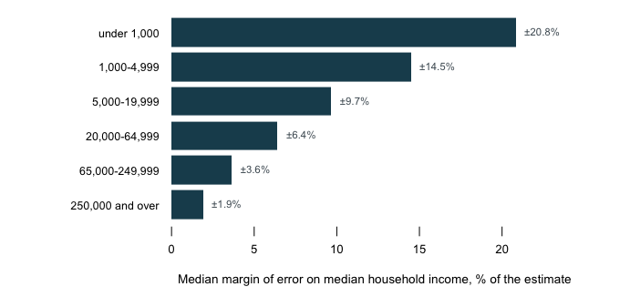

**Figure 1. The margin of error is a function of county size.** Each bar is the median margin on median household income in the five-year file, as a share of the estimate, for counties grouped by population. A bar chart fits this because the question is one magnitude compared across six ordered groups, and length against a common baseline is the comparison the eye does best. Read top to bottom: in counties under a thousand people the median margin is ±20.8%, and it narrows at every step down to ±1.9% in the largest — about 10.9 times tighter.

In the largest counties a margin that tight is good enough to compare places with. In the smallest, ±20.8% is wide enough that a county at the national median is statistically indistinguishable from one well above or below it.

And now put that beside the earlier finding. The places with the widest margins are the small ones — which are exactly the places that have no one-year estimate, and for which the five-year file is the only source. **The uncertainty is largest precisely where there is no alternative.**

## What this data cannot tell you

**It cannot give you a count.** There is no sample size at which a sample becomes a count. The ACS can estimate what share of a county’s households speak Spanish at home; it cannot say how many people live on a block, and the law bars it from apportioning the House. When the question is *exactly how many*, the answer lives in the decennial census, not here.

**One table, one year, one geography.** Everything above is total population and median household income, 2023 vintage, at the county level. The ACS publishes thousands of tables down to the block group, and margins at block-group level are far wider than anything shown here. The shape of the finding does not depend on the table: margins widen as places shrink, and windows disagree where places change. The specific numbers do depend on it.

**The three-year probe is a check on the server, not on the archive.** A 404 means the Bureau does not publish that directory today. Data released between 2007 and 2013 still exists in other forms, and the chapter’s claim is only that the series stopped, which is what the file system shows.

**“County” is not the same list here as in the census chapters.** The five-year file publishes 3,222 county-level rows, and two things separate that list from the one the decennial chapter and the race brief count. Neither is an error. 78 of these rows are Puerto Rico’s municipios, which the ACS covers and the redistricting file leaves out of the apportionment population; that leaves 3,144 in the fifty states and DC. Those chapters still count one fewer, because Connecticut has replaced its eight counties with nine planning regions and the 2023 ACS is tabulated on the new geography while the 2020 census is tabulated on the old.[^8] Same agency, same word, two lists — which is worth knowing before joining one table to another, that is, matching up their rows by a shared county code.

**Why an estimate was controlled is not visible here.** The file records *that* a number was controlled, not the reasoning or the source figure it was controlled to. That the target is the Population Estimates Program is documentation, not something recovered from this file.

**Nothing here measures whether the ACS is right.** Margins of error describe sampling uncertainty — how much the estimate would move if you drew a different sample. They say nothing about who did not answer, who was not asked, or whether the question meant the same thing to everyone. A narrow margin on a badly measured quantity is still narrow.

## What you should have learned

- The ACS is a survey — a sample producing estimates — that lives in the counting section because answering it is required by law, under the same statute that compels the count.
- Pooling years is what reaches small places: the one-year file covers 854 counties, the five-year file all 3,222, and for 2,368 counties the five-year window is the only window there is.
- Recency and reach trade off: 474 of 854 counties differ by more than one per cent between their own one-year and five-year populations, and fast-growing places differ most.
- The margin of error is a function of place size: a median of ±1.9% on household income in the largest counties, ±20.8% in the smallest — widest exactly where the five-year file is the only source.
- Whether a number has a margin at all depends on the table: 3,090 of 3,222 county rows for total population carry none, because they were controlled to the Population Estimates Program.

## Where this data appears in this book

Three briefs in this cluster read the ACS directly:

- Measuring Migration with ACS Flow Estimates — the state-to-state flows one mobility question produces, and how much of that map the margins erase.
- Everybody Moved, Almost Nobody Left — a year of interstate migration drawn as a chord diagram, built on those flow estimates.
- Section 203 Language Coverage Determinations — the ACS-based determinations that decide who is entitled to a ballot they can read.

Beyond the cluster, the ACS turns up wherever a rate needs a denominator with characteristics, a bottom number that is more than a headcount. The ZIP-code brief leans on its small-area tables, and the traffic-stops brief divides one city’s stops by its five-year population estimates.

## Sources

- U.S. Census Bureau. *American Community Survey Summary File*, 2023, table-based format: table B01003 (total population), one-year and five-year; table B19013 (median household income), five-year. https://www2.census.gov/programs-surveys/acs/summary_file/2023/table-based-SF/
- U.S. Census Bureau. *American Community Survey Summary File* archive, vintages 2011–2015, used to establish when the three-year series stopped being published. https://www2.census.gov/programs-surveys/acs/summary_file/
- U.S. Census Bureau. *American Community Survey Design and Methodology*, the Bureau’s own statement of the sample, the rolling collection and the weighting described in the data biography above. https://www.census.gov/programs-surveys/acs/methodology/design-and-methodology.html
- 13 U.S.C. § 221, which makes refusal to answer either instrument an offence, and § 141, which authorises the surveys the Bureau conducts between counts. The obligation those two sections create is what separates this instrument from every survey later in the book. https://www.law.cornell.edu/uscode/text/13/221
- 13 U.S.C. § 195, which permits sampling except for apportionment, and *Department of Commerce v. United States House of Representatives*, 525 U.S. 316 (1999), which read it to bar a sampled apportionment count. https://www.law.cornell.edu/uscode/text/13/195 and https://www.law.cornell.edu/supct/html/98-404.ZS.html
- U.S. Census Bureau. *Understanding and Using American Community Survey Data: What All Data Users Need to Know* (2020) — the 90 percent margins, and how to read them. https://www.census.gov/programs-surveys/acs/library/handbooks/general.html
- U.S. Census Bureau. “Change to County-Equivalents in the State of Connecticut,” *Federal Register*, 6 June 2022 — why the ACS and the 2020 census count Connecticut differently. https://www.federalregister.gov/documents/2022/06/06/2022-12063/change-to-county-equivalents-in-the-state-of-connecticut
- Every published figure for one county’s population, and the exact equality between a one-year total and a population estimate, are laid out in this book’s access chapter.
- ACS state-to-state migration flows, and what their margins do to a finding, are in the migration chapter.

**The data itself**

Every figure above is drawn from these tables. They are plain CSV, they open in a spreadsheet, and they are yours to take further.

`compare.csv`, `controlled.csv`, `diverge.csv`, `instrument.csv`, `margins.csv`, `vintages.csv`, `windows.csv`

**Your turn**

None of these is answered above, and every one can be answered from the tables you just opened.

- `margins.csv` groups counties by size and reports the median margin on median income. Read `median_margin_pct` down the column. At what size of county does the margin stop being a detail and start being the story?
- `diverge.csv` sets the one-year estimate against the five-year estimate for the same county. Sort by `difference_pct`. What kind of county disagrees with itself the most, and which of the two windows would you trust there?
- `controlled.csv` shows that most county rows for total population arrive with no margin at all. Read the `why` column. Is a number with no margin more certain, or just less honest about it?
- `vintages.csv` records which series were published in which year. Read the `series` and `http` columns together. One window is closed. Work out what a researcher lost when it shut.

Rebuild this data yourself, with an AI assistant

```
I want to rebuild a public dataset from its original source, without any
starting files. Please do the following and show your work.

THE SOURCE. U.S. Census Bureau, American Community Survey, 2023
table-based summary files, served plainly from
https://www2.census.gov/programs-surveys/acs/summary_file/2023/table-based-SF/data/
No account or key is needed. Download three files:
- 1YRData/acsdt1y2023-b01003.dat -- total population, one-year
  estimates, about 239 KB
- 5YRData/acsdt5y2023-b01003.dat -- total population, five-year
  estimates, about 18 MB
- 5YRData/acsdt5y2023-b19013.dat -- median household income,
  five-year, about the same size
Each is pipe-delimited: a geographic ID, then estimate and margin
columns. A GEO_ID starting 0500000US is a county. One warning: a
margin of -555555555 is not a margin of minus half a billion. It is a
sentinel meaning the estimate was "controlled" to match another
Bureau program, so no margin applies. Treat it as a flag, not a
number, or your arithmetic will be nonsense.

WHAT TO BUILD.
1. Count the counties in the one-year population file and in the
   five-year one, and how many counties appear only in the five-year
   file -- places for which no one-year estimate exists at all.
2. For counties in both files, compare the two published estimates of
   the same quantity: how many differ by more than 1%, and the median
   absolute difference in people.
3. In each of the two five-year tables, count the county rows whose
   margin field is the controlled sentinel.

CHECK YOUR WORK. The copies this book used were downloaded in August
2026. If your rebuild matches them, you should find:
- 854 counties in the one-year file and 3,222 in the five-year file,
  so 2,368 counties have no one-year estimate
- 474 of the shared counties differ by more than 1%, and the median
  absolute difference is 2,119 people
- 3,090 of the 3,222 population rows carry the sentinel; none of the
  income rows do
A new vintage appears every year under a new directory name; later
numbers mean a different window was measured, not that you erred.
```

[^1]: U.S. Census Bureau, “Sample Size and Data Quality,” American Community Survey, https://www.census.gov/acs/www/methodology/sample-size-and-data-quality/.
[^2]: Every ACS margin is published at the 90 percent confidence level: U.S. Census Bureau, *Understanding and Using American Community Survey Data: What All Data Users Need to Know* (2020), https://www.census.gov/programs-surveys/acs/library/handbooks/general.html.
[^3]: 13 U.S.C. § 195, https://www.law.cornell.edu/uscode/text/13/195.
[^4]: *Department of Commerce v. United States House of Representatives*, 525 U.S. 316 (1999), https://www.law.cornell.edu/supct/html/98-404.ZS.html.
[^5]: U.S. Census Bureau, “The American Community Survey and the 2020 Census,” https://www.census.gov/programs-surveys/acs/about/acs-and-census.html.
[^6]: The controls are described in chapter 11 of the Bureau’s *American Community Survey Design and Methodology*, https://www2.census.gov/programs-surveys/acs/methodology/design_and_methodology/2022/acs_design_methodology_ch11_2022.pdf; the Population Estimates Program is at https://www.census.gov/programs-surveys/popest.html.
[^7]: The Bureau’s own summary of the one-, three- and five-year series, and the end of the middle one, is at https://www.census.gov/programs-surveys/acs/guidance/estimates.html.
[^8]: U.S. Census Bureau, “Change to County-Equivalents in the State of Connecticut,” *Federal Register*, 6 June 2022, https://www.federalregister.gov/documents/2022/06/06/2022-12063/change-to-county-equivalents-in-the-state-of-connecticut.